# Polytomous Latent Class Analysis

Dina Arch

Updated: April 04, 2025

# IMMERSE Project

[figure not shown]

The Institute of Mixture Modeling for Equity-Oriented Researchers, Scholars, and Educators (IMMERSE) is an IES funded training grant (R305B220021) to support education scholars in integrating mixture modeling into their research.

- Please [visit our website](https://immerse.education.ucsb.edu/) to learn more.
- Visit our [GitHub](https://github.com/immerse-ucsb) account to access all the IMMERSE materials.
- Follow us on [Twitter](https://twitter.com/IMMERSE_UCSB)!

How to reference this workshop: Institute of Mixture Modeling for Equity-Oriented Researchers, Scholars, and Educators (2025). IMMERSE Online Resources (IES No. 305B220021). Institute of Education Sciences. https://immerse-ucsb.github.io/

Load packages

```r
library(poLCA)
library(tidyverse)
library(janitor)
library(gt)
library(MplusAutomation)
library(here)
library(glue)

here::i_am("intro_to_polca.Rmd")
```

## Polytomous LCA

Polytomous LCA deals with variables that have more than two categories, such as survey questions with responses like `never`, `sometimes`, and `always`. The workflow of a polytomous LCA model is similar to that of an LCA model with binary indicators. However, polytomous LCA captures more complex response patterns, which can make interpretation a bit trickier. The following code demonstrates an example, along with a visualization of the model.

## Example: Elections

“Two sets of six questions with four responses each, asking respondents’ opinions of how well various traits describe presidential candidates Al Gore and George W. Bush. Also potential covariates vote choice, age, education, gender, and party ID. Source: The National Election Studies (2000).” (poLCA, 2016) [See documentation here](https://cran.r-project.org/web/packages/poLCA/poLCA.pdf)

Two sets of six questions with four responses each, asking respondents’ opinions of how well various traits describe presidential candidates Al Gore and George W. Bush. In the election data set, respondents to the 2000 American National Election Study public opinion poll were asked to evaluate how well a series of traits—moral, caring, knowledgeable, good leader, dishonest, and intelligent—described presidential candidates Al Gore and George W. Bush. Each question had four possible choices: (1) extremely well; (2) quite well; (3) not too well; and (4) not well at all.

### Prepare Data

```r
data(election)

# Detaching packages that mask the dpylr functions
detach(package:poLCA, unload = TRUE)
detach(package:MASS, unload = TRUE)

df_election <-  election %>%
  clean_names() %>%
  select(moralb:intelb) %>%
  mutate(across(everything(),
                ~ as.factor(as.numeric(gsub("\\D", "", .))),
                .names = "{.col}1"))

# Quick summary
summary(df_election)
```

```
##                moralb                  caresb                  knowb
##  1 Extremely well :340   1 Extremely well :155   1 Extremely well :274
##  2 Quite well     :841   2 Quite well     :625   2 Quite well     :933
##  3 Not too well   :330   3 Not too well   :562   3 Not too well   :379
##  4 Not well at all: 98   4 Not well at all:342   4 Not well at all:133
##  NA's             :176   NA's             :101   NA's             : 66
##                leadb                  dishonb                  intelb
##  1 Extremely well :266   1 Extremely well : 70   1 Extremely well :329
##  2 Quite well     :842   2 Quite well     :288   2 Quite well     :967
##  3 Not too well   :407   3 Not too well   :653   3 Not too well   :306
##  4 Not well at all:166   4 Not well at all:574   4 Not well at all:110
##  NA's             :104   NA's             :200   NA's             : 73
##  moralb1    caresb1     knowb1     leadb1    dishonb1   intelb1
##  1   :340   1   :155   1   :274   1   :266   1   : 70   1   :329
##  2   :841   2   :625   2   :933   2   :842   2   :288   2   :967
##  3   :330   3   :562   3   :379   3   :407   3   :653   3   :306
##  4   : 98   4   :342   4   :133   4   :166   4   :574   4   :110
##  NA's:176   NA's:101   NA's: 66   NA's:104   NA's:200   NA's: 73
```

### Descriptive Statistics

```r
ds <- df_election %>%
  pivot_longer(moralb1:intelb1, names_to = "variable") %>%
  count(variable, value) %>%  # Count occurrences of each value for each variable
  group_by(variable) %>%
  mutate(prop = n / sum(n)) %>%
  arrange(desc(variable))

# Create the table
prop_table <- ds %>%
  gt() %>%
  tab_header(title = md("**Descriptive Summary**")) %>%
  cols_label(
    variable = "Variable",
    n = md("*N*"),
    prop = md("Proportion")
  ) %>%
  fmt_number(c("n", "prop"), decimals = 2) %>%  # Format both n and prop columns
  cols_align(
    align = "center",
    columns = c(prop, n)
  )

# View the table
prop_table
```

**Descriptive Summary**

| value | *N* | Proportion |
| --- | --- | --- |
| moralb1 |  |  |
| 1 | 340.00 | 0.19 |
| 2 | 841.00 | 0.47 |
| 3 | 330.00 | 0.18 |
| 4 | 98.00 | 0.05 |
| NA | 176.00 | 0.10 |
| leadb1 |  |  |
| 1 | 266.00 | 0.15 |
| 2 | 842.00 | 0.47 |
| 3 | 407.00 | 0.23 |
| 4 | 166.00 | 0.09 |
| NA | 104.00 | 0.06 |
| knowb1 |  |  |
| 1 | 274.00 | 0.15 |
| 2 | 933.00 | 0.52 |
| 3 | 379.00 | 0.21 |
| 4 | 133.00 | 0.07 |
| NA | 66.00 | 0.04 |
| intelb1 |  |  |
| 1 | 329.00 | 0.18 |
| 2 | 967.00 | 0.54 |
| 3 | 306.00 | 0.17 |
| 4 | 110.00 | 0.06 |
| NA | 73.00 | 0.04 |
| dishonb1 |  |  |
| 1 | 70.00 | 0.04 |
| 2 | 288.00 | 0.16 |
| 3 | 653.00 | 0.37 |
| 4 | 574.00 | 0.32 |
| NA | 200.00 | 0.11 |
| caresb1 |  |  |
| 1 | 155.00 | 0.09 |
| 2 | 625.00 | 0.35 |
| 3 | 562.00 | 0.31 |
| 4 | 342.00 | 0.19 |
| NA | 101.00 | 0.06 |

```r
# Save as a Word doc
#gtsave(prop_table, here("figures", "prop_table.docx"))
```

### Enumeration

This code uses the `mplusObject` function in the `MplusAutomation` package.

```r
lca_enumeration  <- lapply(1:6, function(k) {
  lca_enum  <- mplusObject(

    TITLE = glue("{k}-Class"),

    VARIABLE = glue(
    "categorical = moralb1-intelb1;
     usevar = moralb1-intelb1;
     classes = c({k}); "),

  ANALYSIS =
   "estimator = mlr;
    type = mixture;
    starts = 500 100;
    processors = 10;",

  OUTPUT = "sampstat residual tech11 tech14 svalues;",


  usevariables = colnames(df_election),
  rdata = df_election)

lca_enum_fit <- mplusModeler(lca_enum,
                            dataout=glue(here("poLCA", "election.dat")),
                            modelout=glue(here("poLCA", "c{k}_election.inp")) ,
                            check=TRUE, run = TRUE, hashfilename = FALSE)
})
```

### Table of Fit

```r
source("enum_table.txt")

output_election <- readModels(here("poLCA"), filefilter = "election", quiet = TRUE)

# To see rows:
#seeRows(output_election)

# Arguments for `enum_table`
# 1. readModels objects
# 2-5. Rows of successfully estimated models
fit_table <- enum_table(output_election, 1:6)
fit_table
```

**Model Fit Summary Table**<sup>1</sup>

| Classes | Par | *LL* | BIC | aBIC | CAIC | AWE | BLRT | VLMR | BF | *cmPk* |
| --- | --- | --- | --- | --- | --- | --- | --- | --- | --- | --- |
| 1-Class | 18 | −11,838.63 | 23,811.84 | 23,754.66 | 23,829.84 | 24,000.42 | – | – | 0.0 | <.001 |
| 2-Class | 37 | −10,680.33 | 21,637.30 | 21,519.75 | 21,674.30 | 22,024.92 | <.001 | <.001 | 0.0 | <.001 |
| 3-Class | 56 | −10,184.89 | 20,788.46 | 20,610.55 | 20,844.46 | 21,375.14 | <.001 | <.001 | 0.0 | <.001 |
| 4-Class | 75 | −9,979.58 | 20,519.89 | 20,281.62 | 20,594.89 | 21,305.63 | <.001 | <.001 | 0.0 | <.001 |
| 5-Class | 94 | −9,863.42 | 20,429.62 | 20,130.99 | 20,523.62 | 21,414.41 | <.001 | <.001 | >100 | 1.000 |
| 6-Class | 113 | −9,809.63 | 20,464.09 | 20,105.10 | 20,577.09 | 21,647.93 | <.001 | 0.629 | – | <.001 |

<sup>1</sup> *Note.* Par = Parameters; *LL* = model log likelihood; BIC = Bayesian information criterion; aBIC = sample size adjusted BIC; CAIC = consistent Akaike information criterion; AWE = approximate weight of evidence criterion; BLRT = bootstrapped likelihood ratio test p-value; cmPk = approximate correct model probability.

Save table:

```r
gtsave(fit_table, here("figures", "fit_table.png"))
```

### Information Criteria Plot

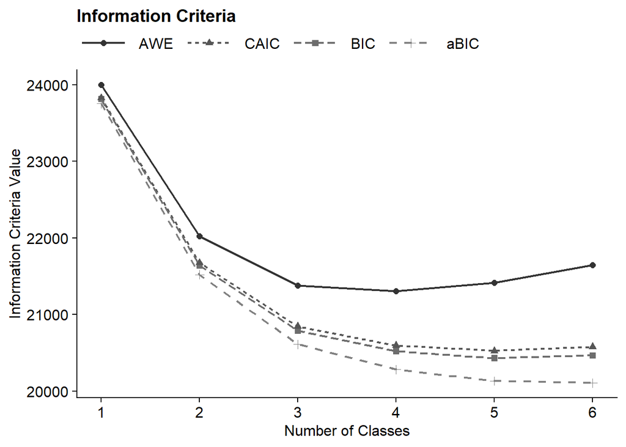

```r
ic_plot(output_election)
```

Save figure:

```r
ggsave(here("figures", "info_criteria.png"), dpi="retina", bg = "white", height=5, width=7, units="in")
```

The functions `poLCA_stacked` and `poLCA_grouped` create visualizations of class probabilities for LCA with polytomous indicators. Each function takes the following arguments:

- **`model_name`**: The LCA model read into R using the `readModels` function from the `MplusAutomation` package.
- **`category_labels`**: A character vector of category labels for the response options (e.g., survey answers).

Note: Double check that the labels are in the correct order!

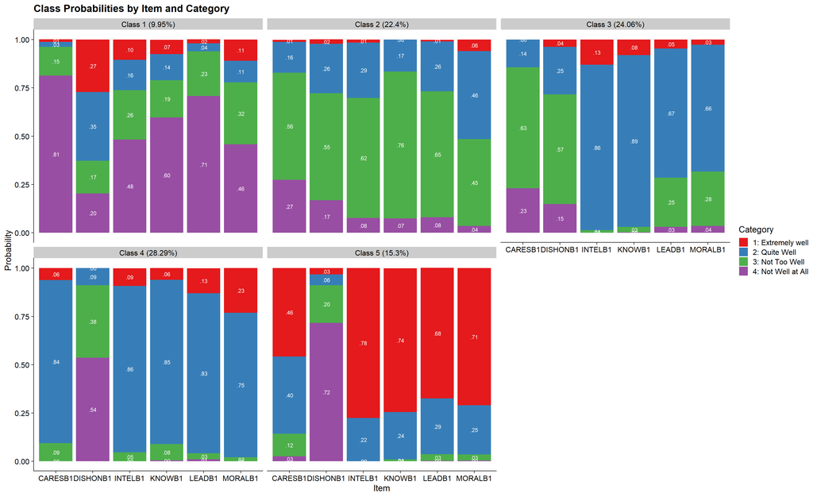

```r
source("poLCA_plot")

poLCA_stacked(output_election$c5_election.out, category_labels = c("1" = "1: Extremely well",
                                                                   "2" = "2: Quite Well",
                                                                   "3" = "3: Not Too Well",
                                                                   "4" = "4: Not Well at All"))
```

Alternative plot

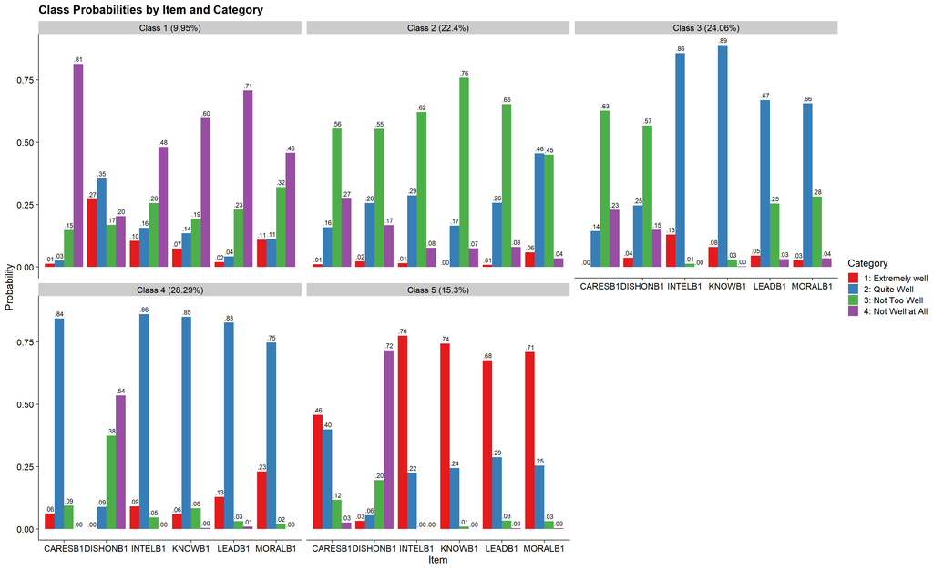

```r
poLCA_grouped(output_election$c5_election.out, category_labels = c("1" = "1: Extremely well",
                                                                   "2" = "2: Quite Well",
                                                                   "3" = "3: Not Too Well",
                                                                   "4" = "4: Not Well at All"))
```

### APA-formatted Plot

```r
# Model
model <- output_election$c5_election.out


# Title
title <- "2000 Descriptions of Presidential Candidate George W. Bush; Item Probabilities by Class"

# Item names
item_labels <- c("CARESB1" = "Caring",
                 "DISHONB1" = "Dishonest",
                 "INTELB1" = "Intelligent",
                 "KNOWB1" = "Knowledgeable",
                 "LEADB1" = "Good Leader",
                 "MORALB1" = "Moral")

# Item Category
category_labels <- c("1" = "1: Extremely well",
                     "2" = "2: Quite Well",
                     "3" = "3: Not Too Well",
                     "4" = "4: Not Well at All")

# Class labels
class_labels <- c("1" = "Poor Decsription (9.95%)",
                  "2" = "Mostly Poor Description (22.40%)",
                  "3" = "In-Between (24.06%)",
                  "4" = "Mostly Well-Described But Not Intelligent (28.29%)",
                  "5" = "Well-Described But Not Intelligent (15.30%)")


#### END EDIT ####
```

#### Extract data needed for plotting

```r
# Extract data needed for plotting
plot_data <- data.frame(model$parameters$probability.scale) %>%
  dplyr::select(est, LatentClass, param, category) %>%
  mutate(
    items = factor(param, labels = item_labels),
    class = factor(LatentClass, labels = class_labels),
    cat = factor(category, labels = category_labels)
  ) %>%
  mutate(class = factor(class, levels = rev(levels(factor(class)))))
```

#### Final grouped bar plot

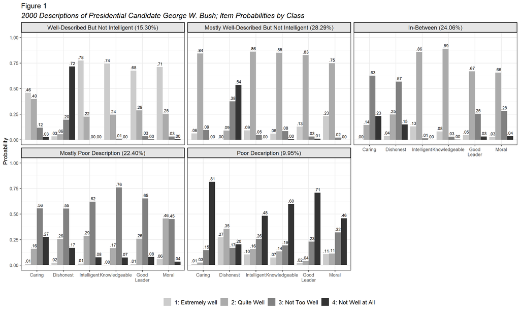

```r
## Plot data
plot_data %>%
  ggplot(aes(
    x = items,
    y = est,
    fill = cat,
    group = cat
  )) +
  geom_bar(stat = "identity", position = "dodge") +
  geom_text(aes(label = sub("^0\\.", ".", sprintf("%.2f", est))),
            position = position_dodge(width = 0.9),
            vjust = -0.5, size = 3) +
  facet_wrap(~ class) +
  ylim(0, 1) +
  scale_x_discrete(
    "",
    labels = function(x)
      str_wrap(x, width = 10)
  ) +
  labs(title = "Figure 1",
       subtitle = title,
       y = "Probability") +
  theme_bw(12) +
  scale_fill_grey(start = 0.8, end = 0.2) + # Gives different shades
  theme(
    text = element_text(family = "sans", size = 12),
    legend.text = element_text(family = "sans", size = 12, color = "black"),
    legend.title = element_blank(),
    legend.position = "bottom",
    legend.justification = "center",
    axis.text.x = element_text(vjust = 1),
    plot.subtitle = element_text(face = "italic", size = 15),
    plot.title = element_text(size = 15),
    strip.background = element_rect(fill = "grey90", color = "black", size = 1),
    strip.text = element_text(size = 12)
  )
```

Save figure:

```r
ggsave(here("figures", "APA_plot1.png"), dpi="retina", bg = "white", height=9, width=15, units="in")
```

#### Alternative

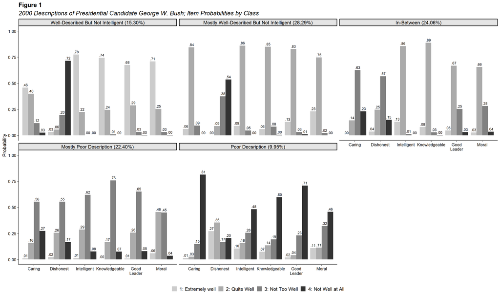

```r
## Plot data
plot_data %>%
  ggplot(aes(
    x = items,
    y = est,
    fill = cat,
    group = cat
  )) +
  geom_bar(stat = "identity", position = "dodge") +
  geom_text(aes(label = sub("^0\\.", ".", sprintf("%.2f", est))),
            position = position_dodge(width = 0.9),
            vjust = -0.5, size = 3) +
  facet_wrap(~ class) +
  ylim(0, 1) +
  scale_x_discrete(
    "",
    labels = function(x)
      str_wrap(x, width = 10)
  ) +
  labs(title = "Figure 1",
       subtitle = title,
       y = "Probability") +
  theme_cowplot(12) +
  scale_fill_grey(start = 0.8, end = 0.2) + # Gives different shades
  theme(
    text = element_text(family = "sans", size = 12),
    legend.text = element_text(family = "sans", size = 12, color = "black"),
    legend.title = element_blank(),
    legend.position = "bottom",
    legend.justification = "center",
    axis.text.x = element_text(vjust = 1),
    plot.subtitle = element_text(face = "italic", size = 15),
    plot.title = element_text(size = 15),
    strip.background = element_rect(fill = "grey90", color = "black", size = 1),
    strip.text = element_text(size = 12)
  )
```

Save figure:

[figure not shown]

```r
ggsave(here("figures", "APA_plot2.png"), dpi="retina", bg = "white", height=10, width=17, units="in")
```